# Project Timeseries

### AR(5):

```r
#ACF decroit vers 0 et 5 pics significatifs dans PACF => AR(5),
#ce qui donne ARIMA(5,1,0) car on a differencie
adj.ar5 <- arima(adjusted, order=c(5,1,0))
adj.ar5
```

```
##
## Call:
## arima(x = adjusted, order = c(5, 1, 0))
##
## Coefficients:
##           ar1      ar2      ar3      ar4      ar5
##       -0.5348  -0.3767  -0.3230  -0.3092  -0.2211
## s.e.   0.0361   0.0396   0.0401   0.0396   0.0363
##
## sigma^2 estimated as 716420:  log likelihood = -5957.12,  aic = 11926.24
```

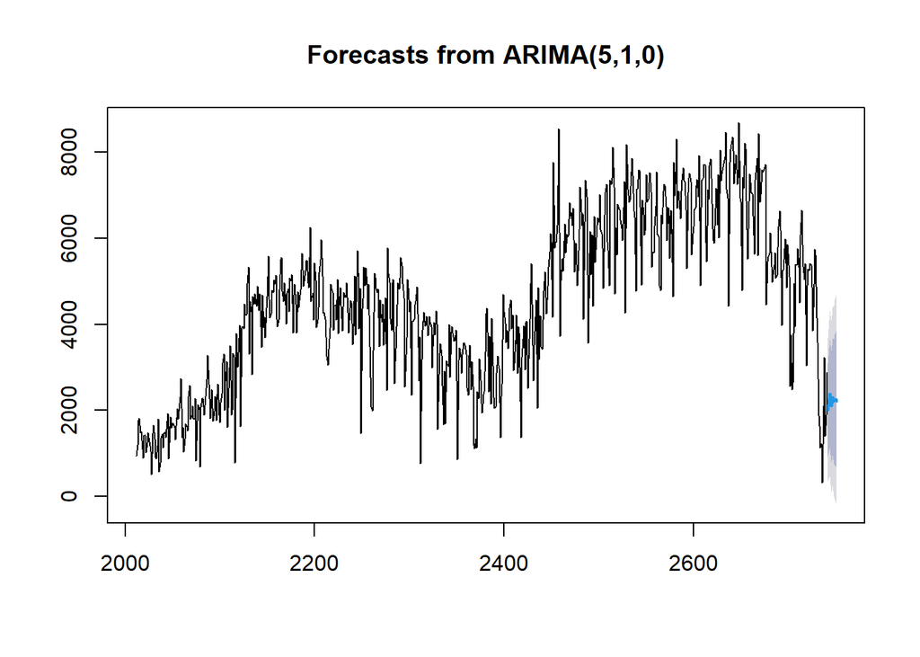

```r
adjforecasts.ar5 <- forecast(adj.ar5, h=10)
plot(adjforecasts.ar5)
```

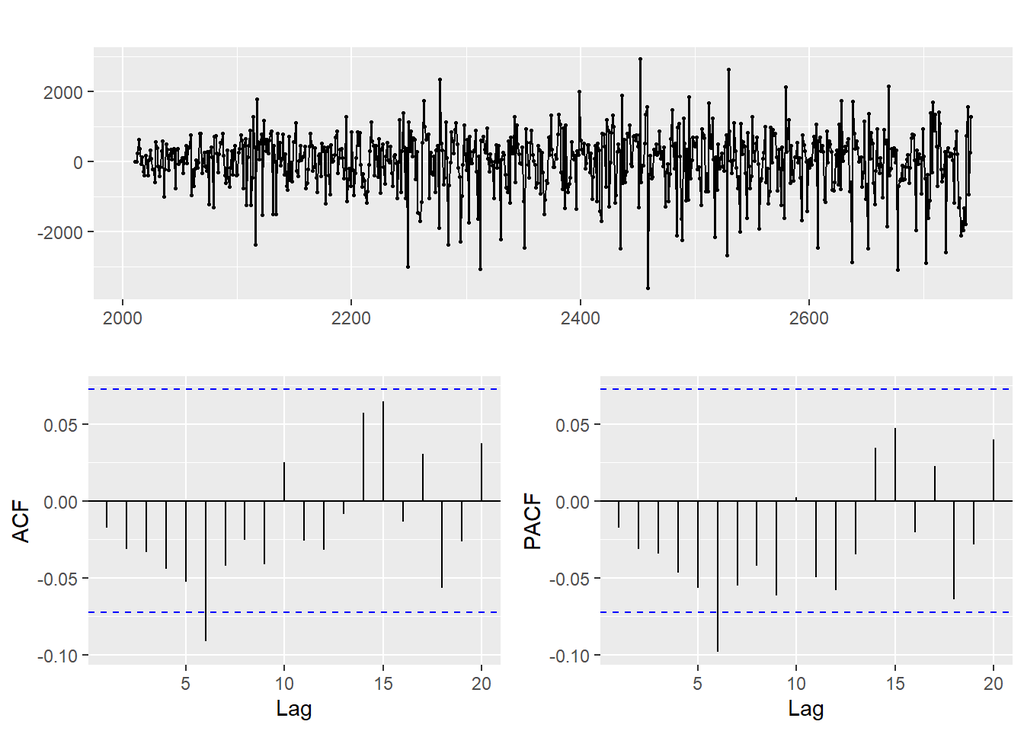

```r
ggtsdisplay(adjforecasts.ar5$residuals, lag =20)
```

```r
Box.test(adjforecasts.ar5$residuals, lag=20, type="Ljung-Box")
```

```
##
##  Box-Ljung test
##
## data:  adjforecasts.ar5$residuals
## X-squared = 26.611, df = 20, p-value = 0.1466
```

Les residuals sont bien un bruit blanc

### ARIMA(5,1,1):

```r
adj.arima <- arima(adjusted, order=c(5,1,1))
adj.arima
```

```
##
## Call:
## arima(x = adjusted, order = c(5, 1, 1))
##
## Coefficients:
##          ar1      ar2      ar3      ar4      ar5      ma1
##       0.2042  -0.0071  -0.0745  -0.0995  -0.0242  -0.7809
## s.e.  0.0836   0.0550   0.0474   0.0474   0.0517   0.0754
##
## sigma^2 estimated as 702069:  log likelihood = -5949.83,  aic = 11913.66
```

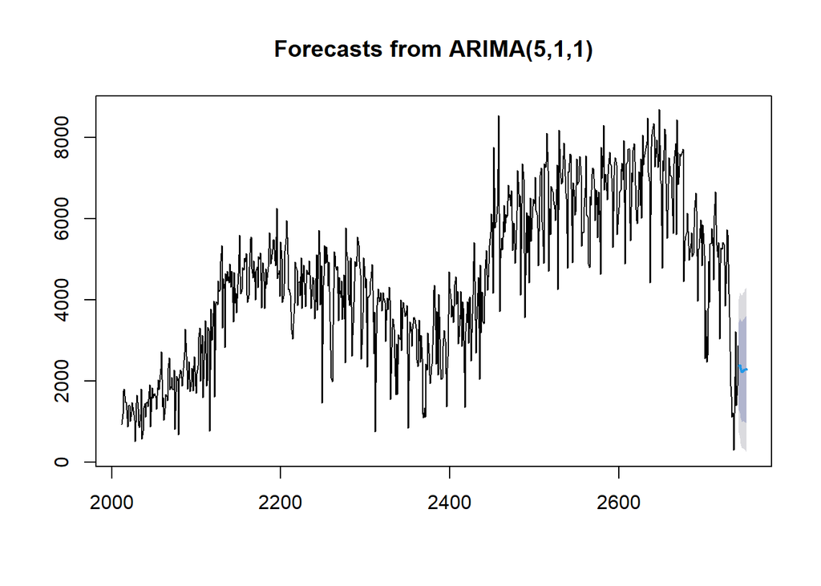

```r
adjforecasts3 <- forecast(adj.arima, h=10)
plot(adjforecasts3)
```

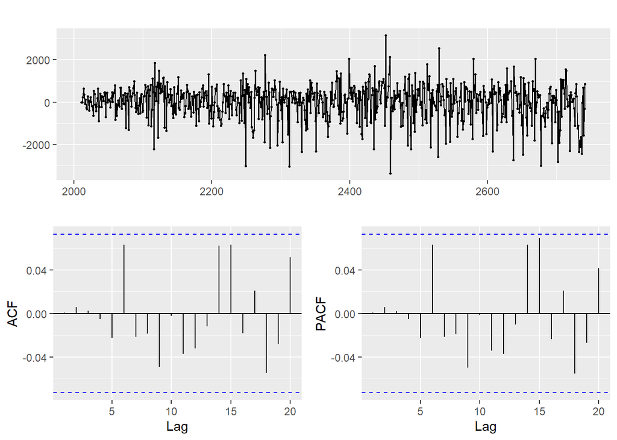

```r
ggtsdisplay(adj.arima$residuals, lag =20)#les residuals sont bien un bruit blanc
```

```r
Box.test(adj.arima$residuals, lag=20, type="Ljung-Box")
```

```
##
##  Box-Ljung test
##
## data:  adj.arima$residuals
## X-squared = 18.935, df = 20, p-value = 0.5261
```

Si on cherche le loglikelihood le plus eleve et minimiser le AIC, le 3eme ARIMA(5,1,1) est le plus approprié, ses résidus se rapprochent le plus d’un bruit blanc. Si on veut se fier au principe de parsimonie, on prendra plutot le MA(1).

## 4)II)

On regarde le modele donné par auto.arima():

```r
autoadj <- auto.arima(adjusted, seasonal=FALSE)
autoadj
```

```
## Series: adjusted
## ARIMA(1,1,1)
##
## Coefficients:
##          ar1      ma1
##       0.2976  -0.8640
## s.e.  0.0448   0.0225
##
## sigma^2 = 711338:  log likelihood = -5953.6
## AIC=11913.2   AICc=11913.23   BIC=11926.98
```

L’Auto Arima nous recommande un ARIMA(1,1,1)

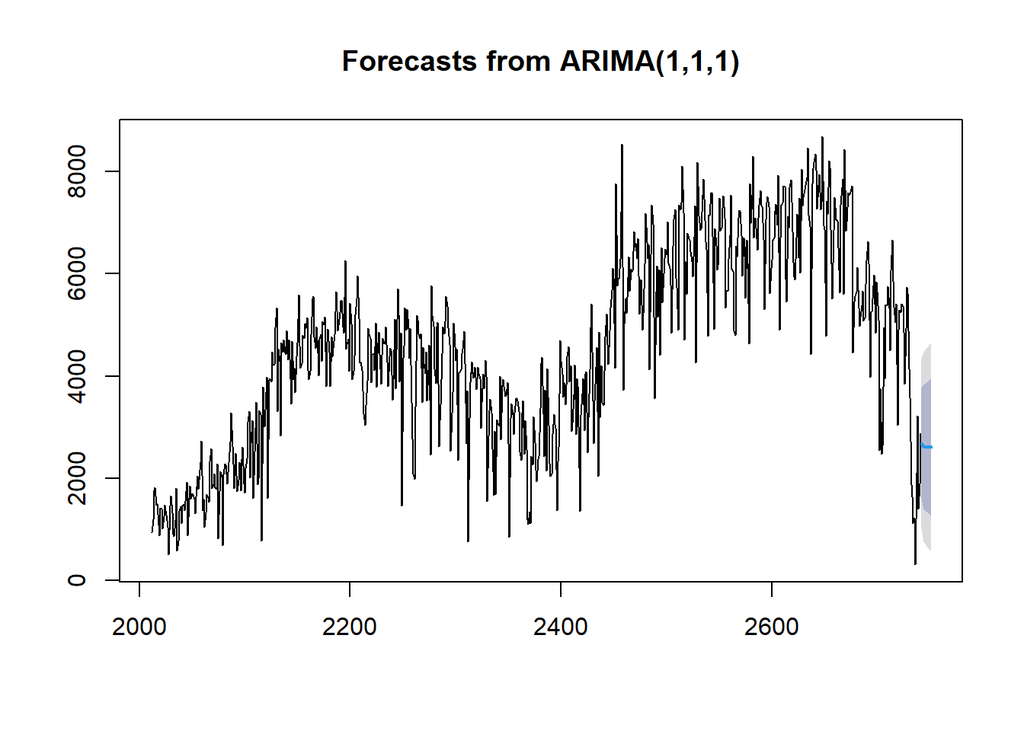

```r
adjforecasts4 <- forecast(autoadj, h=10)
plot(adjforecasts4)
```

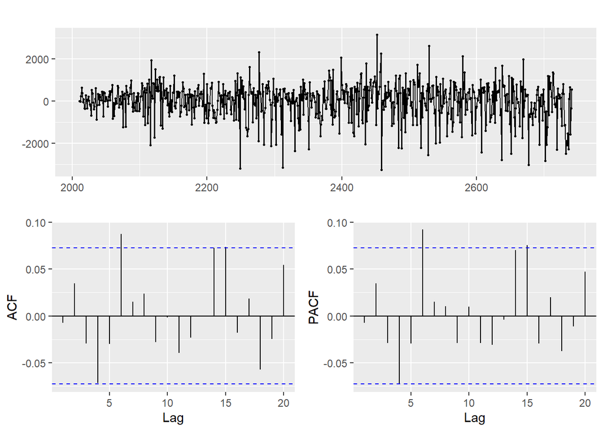

```r
ggtsdisplay(adjforecasts4$residuals, lag =20)#les residuals sont bien un bruit blanc
```

```r
Box.test(adjforecasts4$residuals, lag=20, type="Ljung-Box")
```

```
##
##  Box-Ljung test
##
## data:  adjforecasts4$residuals
## X-squared = 27.938, df = 20, p-value = 0.1109
```

Les résiduels semblent bien etre un bruit blanc.

On compare le modele de auto.arima(), ARIMA(1,1,1), au modele chosit precedemment:

ARIMA(1,1,1) : log likelihood = -5953.6, AIC = 11913.2 ARIMA(5,1,1) : log likelihood = -5949.83, AIC = 11913.66

En termes de log likelihood et AIC ils sont tres similaires, donc on prend le modele avec le moins de parametres,c’est a dire ARIMA(1,1,1).

## 4)III) Evaluer et Itérer:

```r
aic.valuesq <- c()
for (p in c(0:9)){
  for  (q in (0:9)){
    deseasonal_cnt.arima <- arima(adjusted, order = c(p,1,q))
    aic.valuesq <- c(aic.valuesq, deseasonal_cnt.arima$aic)
}}

which.min(aic.valuesq)
```

```
## [1] 78
```

```r
print(aic.valuesq[78])
```

```
## [1] 11903.36
```

```r
#q en premier aic min = 11903.39
```

On trouve que les parametres qui minimisent l’AIC sont p=7 et q=7. Notre modele est donc un ARIMA(7,1,7)

```r
cnt.arima15 <- arima(adjusted, order = c(7,1,7))
cnt.arima15
```

```
##
## Call:
## arima(x = adjusted, order = c(7, 1, 7))
##
## Coefficients:
##           ar1      ar2      ar3      ar4      ar5      ar6     ar7      ma1
##       -0.4307  -0.1673  -0.7504  -0.3065  -0.4638  -0.5681  0.2829  -0.1367
## s.e.   0.0762   0.1369   0.0774   0.1030   0.1089   0.1169  0.0529   0.0702
##           ma2     ma3      ma4     ma5     ma6      ma7
##       -0.2202  0.5450  -0.2235  0.1614  0.3136  -0.7723
## s.e.   0.1084  0.0734   0.1134  0.1225  0.0724   0.0934
##
## sigma^2 estimated as 671920:  log likelihood = -5936.68,  aic = 11903.36
```

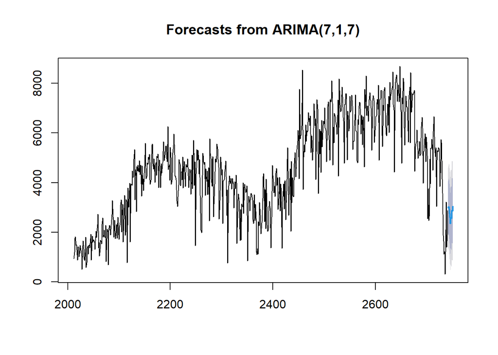

```r
adjforecasts15 <- forecast(cnt.arima15, h=10)
plot(adjforecasts15)
```

On peut apercevoir des variations dans la courbe du forecast et pas juste une ligne droite, ce qui fait apparaitre le forecast plus naturel.

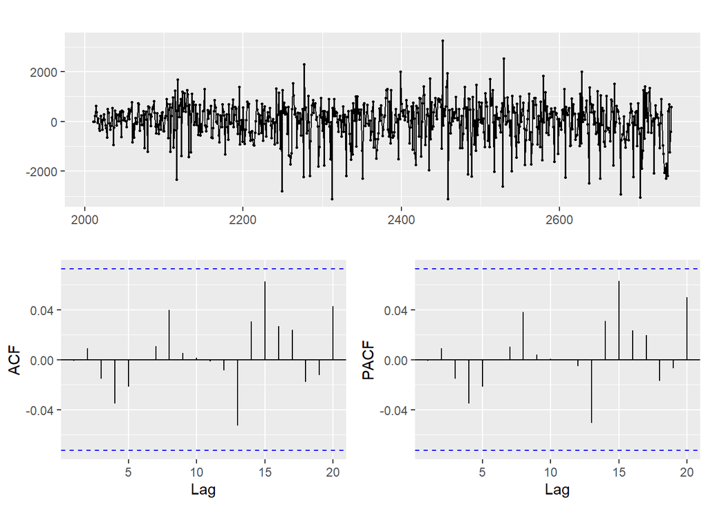

```r
ggtsdisplay(adjforecasts15$residuals, lag =20)#les residuals sont bien un bruit blanc
```

```r
Box.test(adjforecasts15$residuals, lag=20, type="Ljung-Box")
```

```
##
##  Box-Ljung test
##
## data:  adjforecasts15$residuals
## X-squared = 11.195, df = 20, p-value = 0.941
```

Ce modele a des residus qui se rapprochent le plus d’un bruit blanc.

## 4)VI)

On divise les datas en deux ensembles :

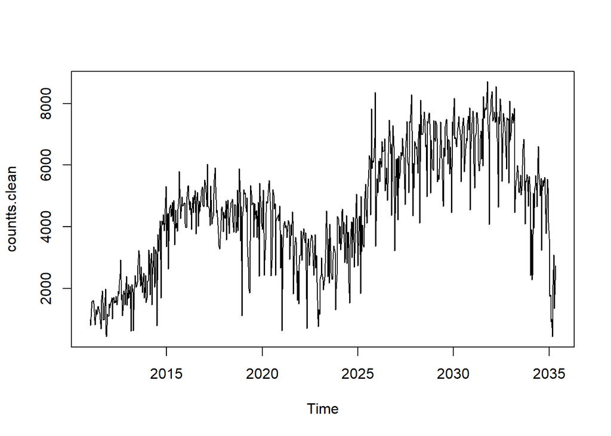

```r
end.time = time(countts.clean)[700]
train.set <- window(countts.clean, end=end.time)
test.set <- window(countts.clean, start=end.time)

plot.ts(countts.clean)
```

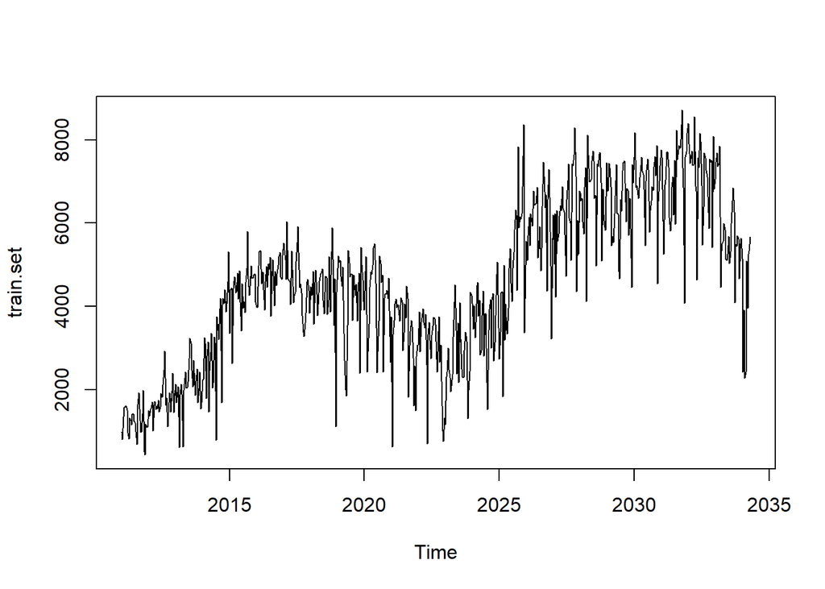

```r
plot.ts(train.set)
```

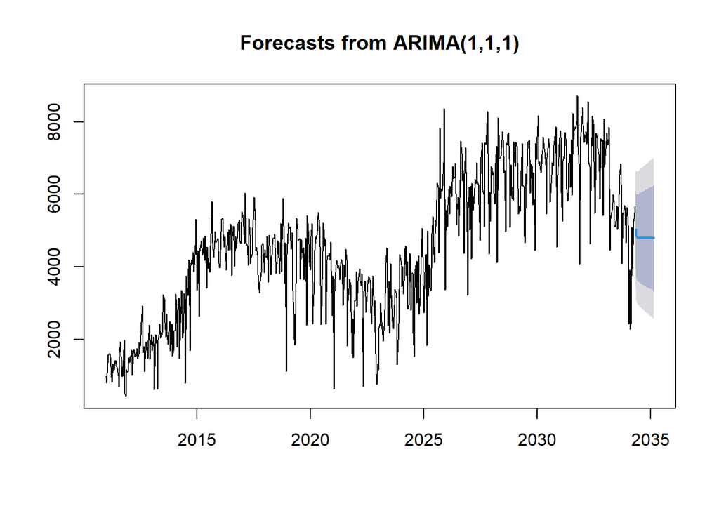

```r
auto <- auto.arima(train.set)
autoforecast <- forecast(auto, h=25)
plot(autoforecast)
```

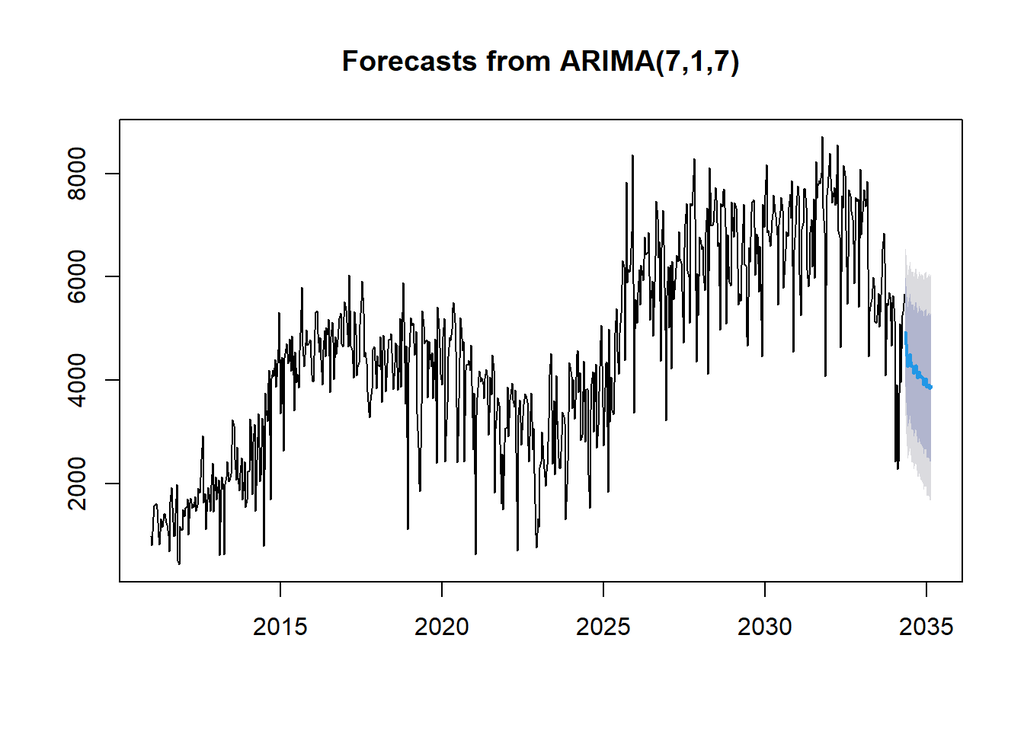

```r
manual <- arima(train.set, order=c(7,1,7))
manualforecast <- forecast(manual, h=25)
plot(manualforecast)
```

La time series originale:

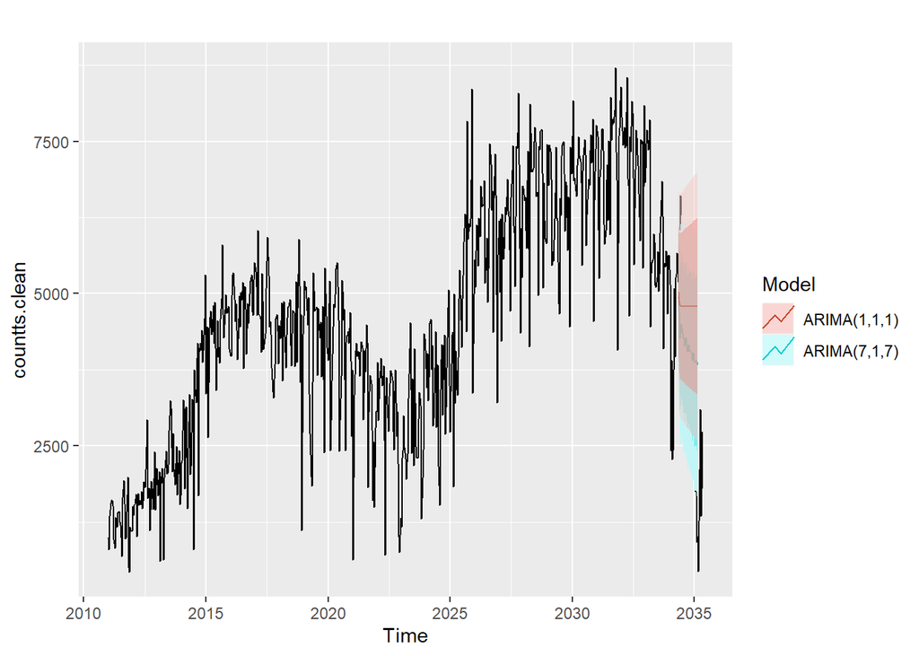

```r
autoplot(countts.clean) +
  autolayer(manualforecast, series = "ARIMA(7,1,7)", alpha = 1) +
  autolayer(autoforecast, series = "ARIMA(1,1,1)", alpha = 0.5) +
  guides(colour = guide_legend("Model"))
```

Les deux modeles donnent des courbes de prediction qui sont plus elevées que la time series originale.

Cependant, On peut voir que Arima(7,1,7) se rapproche plus de la time series originale que Arima(1,1,1)

Interessons nous maintenant a l’accuracy des deux modeles:

```r
accuracy(auto)
```

```
##                    ME     RMSE      MAE       MPE     MAPE      MASE
## Training set 31.70399 839.1331 620.0776 -5.391477 19.36547 0.5692123
##                      ACF1
## Training set -0.004311416
```

```r
accuracy(manual)
```

```
##                    ME     RMSE      MAE       MPE     MAPE      MASE
## Training set 9.905327 824.8849 614.2262 -5.751478 19.32332 0.8833095
##                     ACF1
## Training set 0.002037951
```

On remarque que le modele manuel donne une courbe qui a une allure plus naturelle alors que auto.arima() donne une courbe plus lisse. Par ailleurs les modeles on une difficulte a predire les valeurs eloignes dans le temps. En effect, ils devienent moins precis et l’intervalle de confiance s’elargit de plus en plus.

On prefera quand meme prendre le modele ARIMA(1,1,1) par principe de parsimonie, et pour éviter l’overfitting.